# Stat 579 - Life Expectancy

Nathan Friedrichsen

9/5/2018

# Life Expectancy in Mexico, Canada and the US

## Step-by-step plan of work

1. Read the data
2. Focus on values of Canada
3. Visualize the values for Canada
4. See whether we can find the problem
5. … then we’ll see …

## Reading the data

```r
## Get original life expectancy data from webpage.
url <- "https://raw.githubusercontent.com/Stat579-at-ISU/stat579-at-isu.github.io/master/homework/data/gapminder-5060.csv"
life5060 <- read.csv(url)
head(life5060)
```

```
##       country continent year lifeExp      pop gdpPercap
## 1 Afghanistan      Asia 1952  28.801  8425333  779.4453
## 2 Afghanistan      Asia 1957  30.332  9240934  820.8530
## 3 Afghanistan      Asia 1962  31.997 10267083  853.1007
## 4 Afghanistan      Asia 1967  34.020 11537966  836.1971
## 5     Albania    Europe 1952  55.230  1282697 1601.0561
## 6     Albania    Europe 1957  59.280  1476505 1942.2842
```

```r
## Get additional life expectancy data (70s-80s) from webpage.
url2 <- "https://raw.githubusercontent.com/Stat579-at-ISU/stat579-at-isu.github.io/master/homework/data/gap7080.csv"
gap7080 <- read.csv(url2)
head(gap7080)
```

```
##       country continent year lifeExp      pop gdpPercap
## 1 Afghanistan      Asia 1972  36.088 13079460  739.9811
## 2 Afghanistan      Asia 1977  38.438 14880372  786.1134
## 3 Afghanistan      Asia 1982  39.854 12881816  978.0114
## 4 Afghanistan      Asia 1987  40.822 13867957  852.3959
## 5     Albania    Europe 1972  67.690  2263554 3313.4222
## 6     Albania    Europe 1977  68.930  2509048 3533.0039
```

```r
## Combine both the data sets.
combined_data = rbind(life5060, gap7080)
```

## Focus on the values for Canada

```r
canada <- combined_data %>% filter(country == "Canada")
head(canada)
```

```
##   country continent year   lifeExp      pop gdpPercap
## 1  Canada  Americas 1952     68.75 14785584  11367.16
## 2  Canada  Americas 1957 999999.00 17010154  12489.95
## 3  Canada  Americas 1962     71.30 18985849  13462.49
## 4  Canada  Americas 1967     72.13 20819767  16076.59
## 5  Canada  Americas 1972     72.88 22284500  18970.57
## 6  Canada  Americas 1977     74.21 23796400  22090.88
```

## Visualize

Draw a line for the life expectancy in Canada:

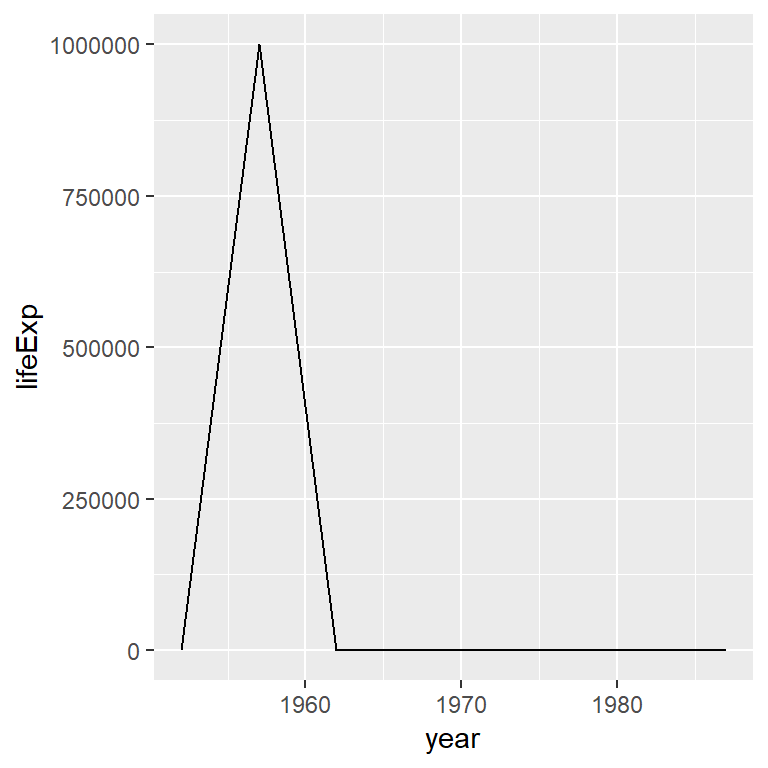

```r
canada %>%
  ggplot(aes(x = year, y = lifeExp)) +
  geom_line()
```

Clearly there is something wrong with the value in 1957.

## Find the problematic value and fix it

```r
canada %>% filter(year == 1957)
```

```
##   country continent year lifeExp      pop gdpPercap
## 1  Canada  Americas 1957  999999 17010154  12489.95
```

```r
canada_fixed <- canada %>% mutate(
  lifeExp = replace(lifeExp, year==1957, 69.96)
)
```

## visualize the fixed data

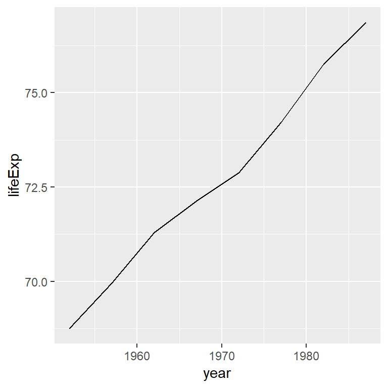

```r
canada_fixed %>% ggplot(aes(x = year, y = lifeExp)) +
  geom_line()
```

## … on to the stretch goal …

Add lines for Mexico and the US, color lines by country and add a legend

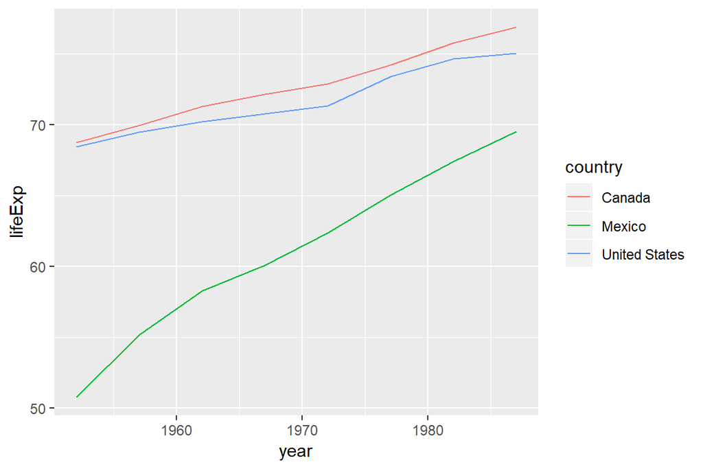

```r
canada_fixed %>%
  ggplot(aes(x = year, y = lifeExp, colour=country)) + geom_line() +
  geom_line(data = combined_data %>%
              filter(country %in% c("United States", "Mexico")))
```

## General Comments:

Before fixing the data point for Canada’s life expectancy in 1957, we can see the answer ‘999999’ doesn’t make sense. After we fix it, we can see there is a positive linear relationship between life expectancy and time.

When we compare the life expectancy lines between U.S., Canada, and Mexico, we see that the U.S. and Canada have roughly the same life expectancies (Canda is slightly higher) throughout the years. The life expectancy lines for both countries fluctuate in the same direction at the same time. Mexico’s life expectancy started much lower than the other two countries, but increased much quicker. The difference between Canada’s and Mexico’s life expectancy went from roughly 20 years to half that of 10 years.